# 14 Soft Limits of Computation

Algorithmics 2025

## Computational Complexity Classes

- *P*, *NP*, and *NP-complete* are all **decision problem** classes.
- *NP-hard* can include **decision problems** or **non-decision problems**.
- **Decision problems** have a “yes/no” answer.
- **P** – solvable in *polynomial time* on a deterministic machine.
- **NP** – solvable on a *nondeterministic* machine in *polynomial time*
  - equivalently, verifiable in polynomial time.

## Reduction

Reduction means **transformation**.

A reduction is an algorithm for converting one problem into another.

If **Problem A** is reducible to **Problem B**:

- Problem A can be transformed into Problem B in polynomial time.
- If Problem B can be solved efficiently, then Problem A can also be solved efficiently.
- Therefore, solving A is **no harder** than solving B.

## Reduction Example

Sudoku to Graph Colouring

1. One vertex per cell in the Sudoku grid.
2. Edges between vertices if cells cannot contain the same number (same row, same column, or same box).
3. Use one colour per digit.
4. The question becomes: Is the graph 9 colourable?
5. Graph Colouring is at least as hard as Sudoku.

## NP-hard

- Every problem in NP can be reduced to NP-hard in polynomial time.
- Not required to be in NP.
  - May not even be a decision problem.
- NP-hard problems that are in NP are called **NP-complete**.

## NP-complete

- In NP (**verifiable** in polynomial time).
- Every problem in NP can be reduced to NP-complete in polynomial time
  - **as hard as any problem in NP**.
- If you can solve one NP-complete problem in polynomial time, you can solve **all** NP problems in polynomial time.

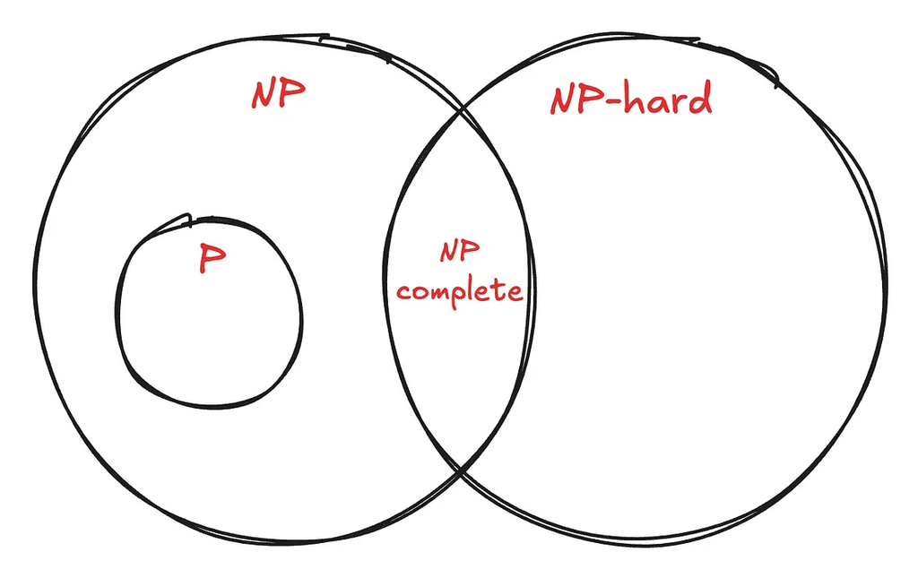

Venn Diagram of Classifications